# Elaboração de relatórios de R com *R Markdown*

Roilan Hernández Valdés e Jônatan Tatsch

15 agosto 2015

# 1 Introdução

Este documento foi escrito em R Markdown. [R Markdown](http://rmarkdown.rstudio.com/) combina sintaxe do [Markdown](http://daringfireball.net/projects/markdown), um formato de texto de escrita fácil para produção de textos em `html`, com trechos de códigos [R](http://www.r-project.org) que são executados e o resultado é impresso no documento final. O R Markdown está disponível no RStudio e sua implementação é baseada no [knitr](http://yihui.name/knitr/) e [pandoc](http://pandoc.org/). Os arquivos gerados com R Markdown recebem a extensão `.Rmd`. Um texto elaborado em R Markdown é produzido clicando-se no ícone `Knit HTML` ou pelo atalho `Ctr+Shift+K` no RStudio.

# 2 A essência do *R Markdown*

- documentos dinâmicos = código + texto, ou
- relatório = linguagem computacional + descrição/discussão dos resultados
- **documentos reproduzíveis**

Por exemplo, para mostrar a expressão usada no R para instalar o pacote `rmarkdown` digitamos o seguinte trecho no corpo do texto do arquivo `.Rmd` criado no RStudio.

````
```{r}
install.packages('rmarkdown', dependencies = TRUE)
install.packages('gcookbook', dependencies = TRUE)
```
````

Que aparecerá da seguinte forma no documento `html`:

```r
install.packages('rmarkdown', dependencies = TRUE)
install.packages('gcookbook', dependencies = TRUE)
```

Um documento dinâmico tem duas partes fundamentais:

- a **primeira** contém a **descrição** do trabalho, discussões que sejam necessárias, teoria, etc.
- a **segunda** parte é composta pelos **blocos de código R** (ou *Chunks* em inglês), geralmente intercalados ao texto.

Nesse documento mostramos os principais elementos de **Markdown** e como construir os **Chunks**.

# 3 Inserir código R no documento.

O código R é inserido através dos *chunks*. Um *chunk* tem a seguinte estrutura:

````
```{r}
Aqui vai o código em R
```
````

## 3.1 Opções do **Chunk**

Cada *chunk* possui parâmetros que permitem definir opções de execução para aquele *chunck*, as principais são as seguintes:

- `chunk2` identificador (ID) do *chunk* que permite encontrar ele mais fácil se ocorrer algum erro (opcional) durante a geração do documento.
- `eval = TRUE` opção para executar o *chunk* quando compilar o documento (default TRUE).
- `cache=TRUE` opção que permite ao *chunk* guardar os dados uma vez calculados (*default* FALSE).
- `message = TRUE` mostra as mensagens de erro (*default* TRUE).
- `echo = TRUE` se FALSE permite eliminar as saídas do chunk (*default* FALSE).

O resto das opções são mostradas ao pressionar a tecla `tab` com o mouse posicionado dentro dos colchetes da linha do **chunk**. Para uma lista completa os parâmetros do *chunck* consulte http://yihui.name/knitr/options/.

````
```{r chunk2, eval=TRUE, message = TRUE, echo = TRUE}
letters
## letras em maiúsculo
LETRAS <- toupper(letters)
LETRAS
x <- LETRAS[LETRAS %in% c('U', 'F', 'S', 'M')]
x
```
````

O *chunck2* será impresso da seguinte forma:

```r
letters
```

```
##  [1] "a" "b" "c" "d" "e" "f" "g" "h" "i" "j" "k" "l" "m" "n" "o" "p" "q"
## [18] "r" "s" "t" "u" "v" "w" "x" "y" "z"
```

```r
## letras em maiúsculo
LETRAS <- toupper(letters)
LETRAS
```

```
##  [1] "A" "B" "C" "D" "E" "F" "G" "H" "I" "J" "K" "L" "M" "N" "O" "P" "Q"
## [18] "R" "S" "T" "U" "V" "W" "X" "Y" "Z"
```

```r
x <- LETRAS[LETRAS %in% c("U", "F", "S", "M")]
x
```

```
## [1] "F" "M" "S" "U"
```

## 3.2 Saídas dos **chunks**

Os resultados dos *chuncks* podem ser mostrados na forma de figuras, tabelas e textos.

````
```{r, warning=FALSE, message=FALSE,comment=''}
    ## carregando a pacote 'ggplot2' para gráficos elegante
    library(ggplot2)
    ## pacote que contém conjunto de dados de temperatura
    library(gcookbook)
    ## Mostrando as primeiras linhas da tabela 'climate' que pertenece ao pacote
    head(climate)
    ## Usando a função qplot() para plotar a série de temperatura global
    qplot(x = Year, y = Anomaly1y, data = climate) + geom_smooth()
    ## Usando apenas a função plot()
    plot(x = climate$Year, y = climate$Anomaly1)
    ## regressão linear
    reg <- lm(Anomaly1y ~ Year, data = climate)
    ## extraindo o coeficiente angular (°C/ano) da reta
    ## convertendo para °C/100 anos
    tendencia <- coef(reg)[2] * 100
```
````

```r
    ## Carregando a pacote 'ggplot2' para gráficos elegante
    library(ggplot2)
    ## pacote que contém conjunto de dados de temperatura
    library(gcookbook)
    ## Mostrando as primeiras linhas da tabela 'climate' que pertenece ao pacote
    head(climate)
```

```
    Source Year Anomaly1y Anomaly5y Anomaly10y Unc10y
1 Berkeley 1800        NA        NA     -0.435  0.505
2 Berkeley 1801        NA        NA     -0.453  0.493
3 Berkeley 1802        NA        NA     -0.460  0.486
4 Berkeley 1803        NA        NA     -0.493  0.489
5 Berkeley 1804        NA        NA     -0.536  0.483
6 Berkeley 1805        NA        NA     -0.541  0.475
```

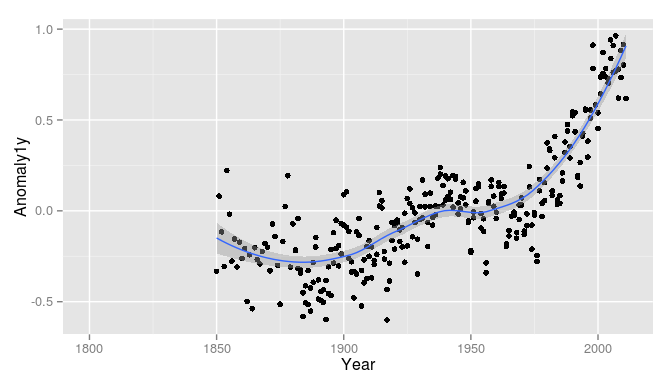

```r
    ## Usando a função qplot() para plotar a série de temperatura global
    qplot(x = Year, y = Anomaly1y, data = climate) + geom_smooth()
```

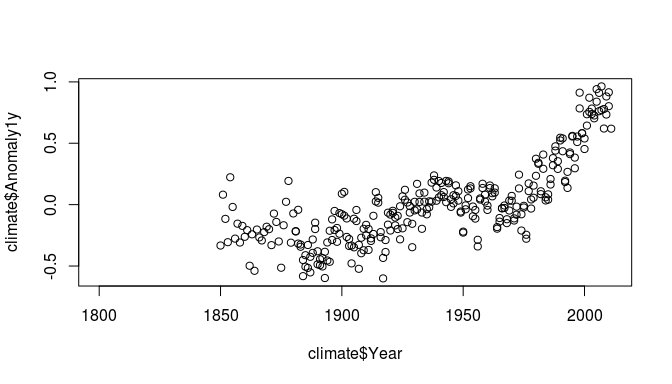

```r
    ## Usando apenas a função plot()
    plot(x = climate$Year, y = climate$Anomaly1y)
```

```r
    ## regressão linear
    reg <- lm(Anomaly1y ~ Year, data = climate)
    ## extraindo o coeficiente angular (°C/ano) da reta
    ## convertendo para °C/100 anos
    tendencia <- coef(reg)[2] * 100
    tendencia
```

```
     Year
0.5929518
```

Podemos fazer outro **chunk** para mostrar as tabelas.

````
```{r}
    ## pacote com a função kable para saída de tabelas
    library(knitr)
    ## Aplicando a função 'summary()' ao dataframe airquality.
    s <- summary(airquality)
    ## Convertendo o formato da saída das tabelas
    kable(s, caption = 'Tabela 1: Resumo estatístico dos de qualidade do ar')
```
````

```r
## pacote com a função kable para saída de tabelas
library(knitr)
## pacote com dados de temperatura global
library(gcookbook)
## Aplicando a função 'summary()' ao dataframe airquality.
s <- summary(airquality)
## Convertendo o formato da saída das tabelas
kable(s, caption = "Tabela 1: Resumo estatístico dos dados de 'qualidade do ar' de NY")
```

Tabela 1: Resumo estatístico dos dados de ‘qualidade do ar’ de NY

|  | Ozone | Solar.R | Wind | Temp | Month | Day |
| --- | --- | --- | --- | --- | --- | --- |
|  | Min. : 1.00 | Min. : 7.0 | Min. : 1.700 | Min. :56.00 | Min. :5.000 | Min. : 1.0 |
|  | 1st Qu.: 18.00 | 1st Qu.:115.8 | 1st Qu.: 7.400 | 1st Qu.:72.00 | 1st Qu.:6.000 | 1st Qu.: 8.0 |
|  | Median : 31.50 | Median :205.0 | Median : 9.700 | Median :79.00 | Median :7.000 | Median :16.0 |
|  | Mean : 42.13 | Mean :185.9 | Mean : 9.958 | Mean :77.88 | Mean :6.993 | Mean :15.8 |
|  | 3rd Qu.: 63.25 | 3rd Qu.:258.8 | 3rd Qu.:11.500 | 3rd Qu.:85.00 | 3rd Qu.:8.000 | 3rd Qu.:23.0 |
|  | Max. :168.00 | Max. :334.0 | Max. :20.700 | Max. :97.00 | Max. :9.000 | Max. :31.0 |
|  | NA’s :37 | NA’s :7 | NA | NA | NA | NA |

## 3.3 Códigos R dentro de linhas

Podemos usar o R em expressões dentro de uma linha de texto, para mostrar o valor de uma variável ou efetuar um cálculo. Por exemplo, para obtermos o valor resultante de 2 + 2 escrevemos ` r 2 + 2 ` e o R colocará o resultado naquela posição do texto.

Por exemplo, a sentença:

- A tendência da temperatura do ar média global é de ` r round(tendencia, 2) ` °C/100 anos.

ficará

- A tendência da temperatura do ar média global é de 0.59 °C/100 anos.

Assim como,

- A média de uma sequência de números inteiros 1 até 10 é ` r mean(1:10) `.

ficará:

- A média de uma sequência de números inteiros de 1 até 10 é 5.5.

# 4 Markdown

## 4.1 Cabeçalhos

**Cabeçalhos** (ou *headers* em inglês) são definidos para construção do índice de seções ou capítulos do documento (*table of content, TOC*) que são ‘lincados’ às seções.

```
 # Seção - nível 1
 ## Subseção - nível 2
 ### Subsubseção - nível 3
 e assim por diante
 ...
```

## 4.2 Parágrafos

Um parágrafo é uma ou mais linhas de texto, seguido de uma ou mais linha em branco.

**Novas linhas são tratadas como espaços**, para que possa organizar seus parágrafos como você gosta.

Se você precisar de uma quebra de linha, insira **dois ou mais espaços no final de uma linha**.

## 4.3 Aparência

A aparência e formato do documento final impresso é definido por parâmetros definido no cabeçalho texto escrito no arquivo `.Rmd`. Veja no exemplo abaixo, onde são definidos parâmetros para o formato de saída do arquivo (`output: html_document`), a inclusão de índice (`toc = TRUE`), opções para figuras (`fig_width: 7`, `fig_height: 6`, `fig_caption: true`), a opção para realce da sintaxe do código R (`highlight: tango`), o tema do `html` (`theme: united`). Para mais informações consulte http://rmarkdown.rstudio.com/markdown_document_format.html.

```python
    ---
    title: "Meu novo projeto"
    author: Nome Sobrenome
    output:
         html_document:
            theme: united [default, cerulean, journal, flatly, readable, spacelab, united, cosmo]
            highlight: tango [default, tango, pygments, kate, monochrome, espresso, zenburn, haddock, textmate]
            number_sections: true
            toc: true
            fig_width: 7
            fig_height: 6
            fig_caption: true
    ---
```

## 4.4 Blocos de códigos sem execução (*Verbatim*)

Para inserir um trecho de código de uma linguagem de programação é preciso inserir 4 espaços antes das linhas de código.

````
  ```fortran
          if ( a .lt. 3) then
            write(*,*) y,w
          end if
  ```
````

O código impresso no `html` aparecerá da seguinte forma:

```fortran
    if ( a .lt. 3) then
      write(*,*) y,w
    end if
```

## 4.5 Listas

Para produzir uma lista são usados os símbolos: `+` , `*` , `-`. Uma lista suporta vários níveis de subitens. Os subitens devem separados por quatro espaços ou um *tab*.

```
 * one
     - subitem
 * two
     - subitem
         - subsubitem
 * three
```

- one
  - subitem
- two
  - subitem
    - subsubitem
- three

## 4.6 Linhas horizontais

Para inserir uma linha horizontal pode-se usar:

```markdown
 * * *

 ou

 - - -
```

que será impresso como

ou

É importante notar a quebra de linha entre cada linha de caracteres.

## 4.7 Citações diretas

Citação direta curta:

> É eRRando que se aprende R. (Jônatan Tatsch)

Citação direta longa em blocos:

> Esta é uma citação com dois parágrafos. Lorem ipsum dolor sit amet, consectetuer adipiscing elit. Aliquam hendrerit mi posuere lectus. Vestibulum enim wisi, viverra nec, fringilla in, laoreet vitae, risus.

> Donec sit amet nisl. Aliquam semper ipsum sit amet velit. Suspendisse id sem consectetuer libero luctus adipiscing.

## 4.8 Tabelas

As tabelas devem ter uma linha para cada fila, com alinhamento definido pela posição relativa a linha pontilhada dos nomes das colunas. A descrição da tabela precisa ter o formato `Table:` ou apenas `:`, a posição definida é acima da tabela.

```
  direita     esquerda   Centro    Default
  -------     ------   ---------   -------
       12     12          12           12
      123     123         123         123
        1     1            1            1
  Table:  Tabela 1. Demonstração da sintaxe para uma tabela.
```

Tabela 1. Demonstração da sintaxe para uma tabela.

| direita | esquerda | Centro | Default |
| --- | --- | --- | --- |
| 12 | 12 | 12 | 12 |
| 123 | 123 | 123 | 123 |
| 1 | 1 | 1 | 1 |

```
  : Amostra de tabela com grades.

  +---------------+---------------+--------------------+
  | Fruit         | Price         | Advantages         |
  +===============+===============+====================+
  | Bananas       | $1.34         | - built-in wrapper |
  |               |               | - bright color     |
  +---------------+---------------+--------------------+
  | Oranges       | $2.10         | - cures scurvy     |
  |               |               | - tasty            |
  +---------------+---------------+--------------------+
```

Amostra de tabela com grades.

Fruit

Price

Advantages

Bananas

$1.34

- built-in wrapper
- bright color

Oranges

$2.10

- cures scurvy
- tasty

Uma facilidade para construir tabelas em Markdown é o http://www.tablesgenerator.com/markdown_tables que permite montar a tabela e criar o código para você colá-lo no seu documento `.Rmd`.

## 4.9 Ênfase de texto

Para destacar texto usa-se geralmente as palavras em *itálico* (`_itálico_` ou `*itálico*`) ou em **negrito** (`__negrito__` ou `**negrito**`).

Um texto sobrescrito 2<sup>10</sup> é definido `2^10^` e o subscrito (H<sub>2</sub>O) da forma `H~2~O`.

## 4.10 Links

Para incluir link de um site és só fechar o endereço da web entre `< >`:

```
<http://google.com>

<sam@green.eggs.ham>
```

http://google.com

sam@green.eggs.ham

As vezes queremos dar a determinada frase um link que vincula uma explicação melhor do que foi abordado.

“O *R Markdown* tem ampla documentação, veja o [cartão de referência](http://www.rstudio.com/wp-content/uploads/2015/03/rmarkdown-reference.pdf) e o [site oficial](http://rmarkdown.rstudio.com/)) que podem ser consultados a qualquer momento tendo-se uma conexão à internet.”

Aqui tem um [link](http://cran.r-project.org/doc/contrib/Short-refcard.pdf) dentro da linha de texto que podemos expressar também com um título [cartão de referência](http://cran.r-project.org/doc/contrib/Short-refcard.pdf).

```
 Aqui tem um [link](http://cran.r-project.org/doc/contrib/Short-refcard.pdf) dentro da linha de texto que podemos expressar também com um título [cartão de referência](http://cran.r-project.org/doc/contrib/Short-refcard.pdf "Manter esse Cartão de referência para consultas").
```

## 4.11 Figuras

Para a inserir figuras o procedimento é exatamente como o de um link, só que precedido por um símbolo `!`.

Vamos criar um link para o endereço da imagem:

```
[Cachoeira do Abade](http://upload.wikimedia.org/wikipedia/commons/c/c5/Cachoeira_do_Abade_AGO_2008.jpg)
```

[Cachoeira do Abade](http://upload.wikimedia.org/wikipedia/commons/c/c5/Cachoeira_do_Abade_AGO_2008.jpg)

Ao acrescentarmos o símbolo `!` no início, obtemos a imagem no documento.

```markdown
![Cachoeira do Abade](http://upload.wikimedia.org/wikipedia/commons/c/c5/Cachoeira_do_Abade_AGO_2008.jpg)
```

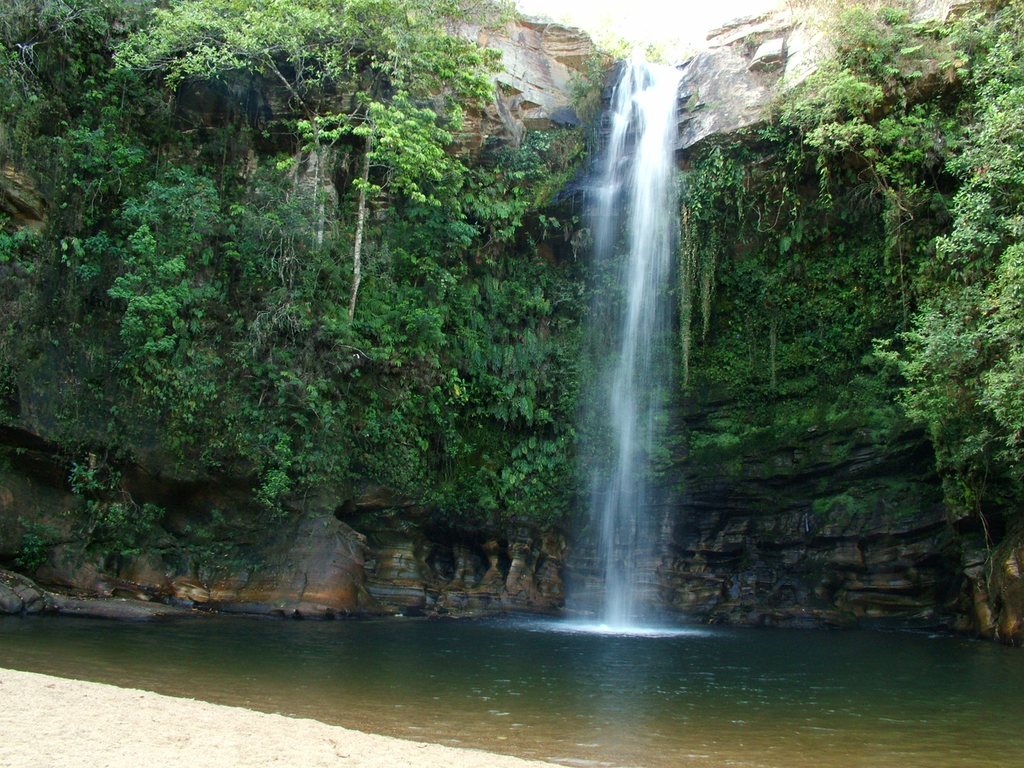

O procedimento para inserir figuras do seu computador é o mesmo, só o endereço é substituído pelo caminho até o nome do arquivo.

## 4.12 Expressões matemáticas

Nossa área de estudo geralmente requer análises baseadas em equações. Para inserir expressões matemáticas no *R Markdown* é da mesma forma usada em [Latex](http://pt.wikipedia.org/wiki/LaTeX). Existem diversos tutoriais sobre equações em Latex:

- http://web.eecs.utk.edu/~mgates3/docs/latex.pdf(pag 16-25)
- http://meta.math.stackexchange.com/questions/5020/mathjax-basic-tutorial-and-quick-reference
- ftp://ftp.ams.org/pub/tex/doc/amsmath/short-math-guide.pdf
- http://elevatorlady.ca/doc/refcard/expressions.html
- [Editor online de equações](http://www.codecogs.com/latex/eqneditor.php?lang=pt-br)

Para expressões dentro de uma linha as equações são escritas entre os símbolos `$ $`, por exemplo, $y=f(x)$ foi gerada com `$y=f(x)$`. Mas se a equação for muito complexa é melhor colocá-la sozinha entre parágrafos de texto, duplicando o mesmo símbolo `$$ $$`, exemplo:

```latex
 $$\psi = \psi_e \left(\dfrac{\theta}{\theta_s}\right)^{-b}$$
```

produz:

$\psi = \psi_e \left(\dfrac{\theta}{\theta_s}\right)^{-b}$

# 5 Simulação da resolução de uma Lista de exercícios.

A resolução das listas do curso deverão ser entregues no formato R Markdown. O arquivo `.Rmd` deverá ser enviado via [Moodle](http://nte.ufsm.br/moodle2_UAB/). O arquivo deve ser nomeado seguindo o padrão `nomedoaluno_lista1.Rmd`. O documento deve conter a identificação do aluno, o enunciado de cada questão seguido de sua resolução que deve incluir a descrição, comentários e a interpretação dos resultados quando for o caso.

## 5.1 Lista 1. Exercícios da Unidade 1 do Curso de ADAR-UFSM.

1. Gere uma sequência numérica 1 a 365 com 2 repetições de cada dia.
2. Gere uma sequência `x` de -100 até 100, com intervalo de 0,5.
3. Gere uma variável `A` que resulta do seno de uma sequência numérica de -1 até 1 com mesmo tamanho do vetor `x` da questão anterior.
4. Calcule o vetor resultante $y = exp(-0.07Ax)cos(x+\frac{\pi }{2}))$.
5. Faça um gráfico do tipo linha relacionando as duas variáveis.

# 6 Referências importantes

- [documentação básica](http://rmarkdown.rstudio.com/)
- knitr manual
- [knitr graphics manual](http://yihui.name/knitr/)
- [exemplos](https://github.com/yihui/knitr-examples)
- [latex-mathjax](http://meta.math.stackexchange.com/questions/5020/mathjax-basic-tutorial-and-quick-reference)
- latex-guia curta de escritura de expressões matemáticas,
- [latex-expressões](http://elevatorlady.ca/doc/refcard/expressions.html).